# Лабораторна робота №1. Створення основи типового Data Science-проєкту

[Дерикон А. В..](https://github.com/Artem418k), 2024

2024-11-11

**Мета:** *“Швидкий старт” для створення бази Data Science-проекту у середовищі RStudio із застосуванням концепції “грамотного програмування” засобами мови програмування R, пакету RMarkdown та системи комп’ютерної верстки LaTeX*.

## Приклад створення Markdown-документу

### Виконання завдання

1. Створюємо документ R Markdown.
2. Налаштовуємо потрібним чином YAML-заголовок документу, у якому задаються метадані всього документу (рис. 1).

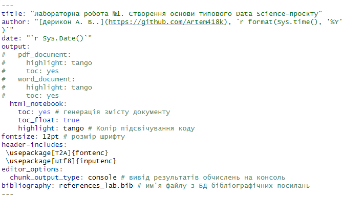

*Рис. 1. Вигляд YAML-заголовку для документу, який ви зараз читаєте*

3. Пишемо код на R засобами базової графіки у відповідній зоні, яка називається чанком:

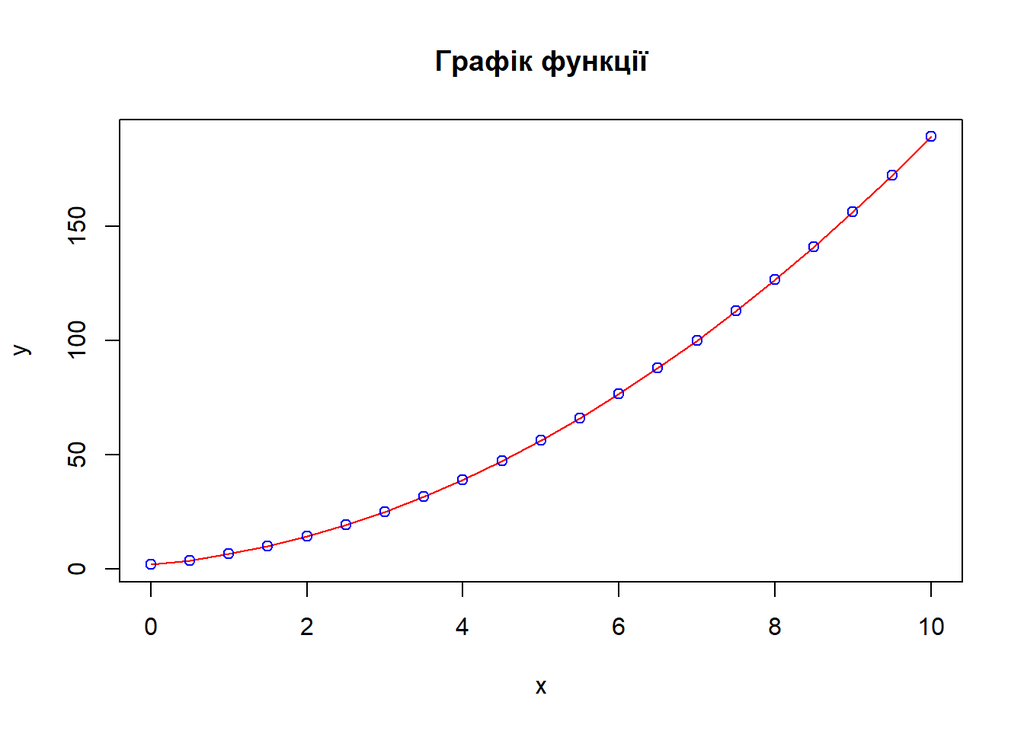

```r
# Задаємо параметри функції
b0 <- 2
b1 <- 3
b2 <- 1.57

# Задаємо область визначення

x <- seq(0, 10, 0.5)
y <- b0 + b1 * x + b2 * x^2

plot(x, y,
     type = "l",
     col = "red",
     main = "Графік функції",
     xlab = "x",
     ylab = "y"
     )
points(x, y,
       col = "blue")
```

```r
df <- data.frame(x = x, y = y) # створюємо таблицю даних
```

4. Продемонструємо можливості пакету `rio` (Chan et al. 2018) для експорту (імпорту) даних на диск (з диску).

```r
# install.packages("rio") # інсталяція пакету
library(rio) # підключення пакету
export(df, "data/data.csv")
```

5. Виконуємо імпорт даних із файлу і візуалізацію у вигляді таблиці.

```r
dfNew <-  import("data/data.csv")

# Таблиця засобами knitr
knitr::kable(head(dfNew),
             caption = "_Табл. 1. Фрагмент таблиці даних_")
```

*Табл. 1. Фрагмент таблиці даних*

| x | y |
| --- | --- |
| 0.0 | 2.0000 |
| 0.5 | 3.8925 |
| 1.0 | 6.5700 |
| 1.5 | 10.0325 |
| 2.0 | 14.2800 |
| 2.5 | 19.3125 |

```r
# Таблиця засобами stargazer
# stargazer::stargazer(head(dfNew),
#                      type = "html",
#                      summary = FALSE,
#              title = "_Табл. 1. Фрагмент таблиці даних_")


# Таблиця засобами xtable
# print(xtable::xtable(head(dfNew),
#                      type = "html",
#                      html.table.attributes="border=0",
#                      summary = FALSE,
#              caption = "_Табл. 1. Фрагмент таблиці даних_"))
```

6. Формуємо результуючу таблицю.

*Табл. 2. Параметри функції*

| Параметр | Значення |
| --- | --- |
| $b_0$ | 2 |
| $b_1$ | 3 |
| $b_2$ | 1.57 |
| $x_1$ | 0 |
| $x_2$ | 10 |

## Індивідуальні завдання

### Перше завдання

Побудувати графік функції $y(x) = \frac{a \sin(bx) + c \cdot \cos(x)}{\ln(x + d)}$ для діапазону $x \in [x_1; x_2]$

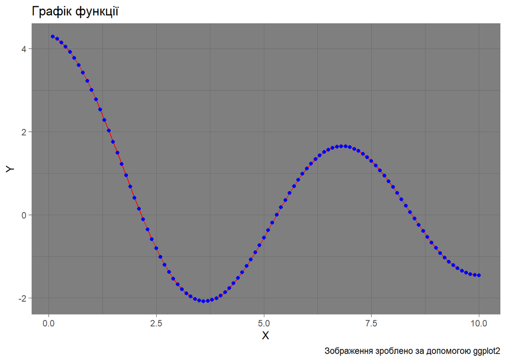

```r
# Задаємо параметри функції
a <- 2
b <- 1
c <- 3
d <- 2

# Задаємо область визначення X

x <- seq(0.1, 10, length.out = 100)

#Визначаемо значення по заднiй функцiї
y <- (a * sin(b * x) + c * cos(x)) / log(x + d)

df <- data.frame(x = x, y = y) # створюємо таблицю даних

#Пiдключаемо ggplot2
library(ggplot2)

# Create a red lineplot in ggplot2
ggplot(df, aes(x = x, y = y)) +
  geom_line(color = "red") +                 # Червона линия
  geom_point(color = "blue") +               # Блакитнi точки
  labs(x = "X", y = "Y",
       title = "Графік функції",
       caption = "Зображення зроблено за допомогою ggplot2") +
  theme_dark()
```

2. Виконуємо експортуємо даних у файл *data2.csv*.

```r
library(rio) # підключення пакету
export(df, "data/data2.csv")
```

3. Виконуємо імпорт даних із файлу і візуалізацію у вигляді таблиці.

```r
dfNew <-  import("data/data2.csv")

# Таблиця засобами knitr
knitr::kable(head(dfNew),
             caption = "_Табл. 3. Фрагмент таблиці даних першого індивідуального завдання_")
```

*Табл. 3. Фрагмент таблиці даних першого індивідуального завдання*

| x | y |
| --- | --- |
| 0.1 | 4.292383 |
| 0.2 | 4.232998 |
| 0.3 | 4.150573 |
| 0.4 | 4.045855 |
| 0.5 | 3.919715 |
| 0.6 | 3.773154 |

### Друге завдання

Побудувати графік функції $y(x)=\frac{\sqrt{a+b*sin(x)}}{ln(x+c)}$ для діапазону $x \in [x_1;x_2]$.

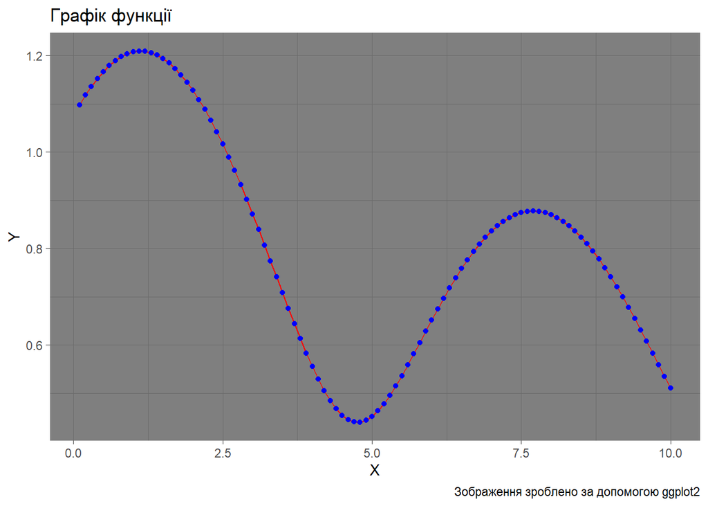

```r
# Задаємо параметри функції
a <- 3
b <- 2
c <- 5

# Задаємо область визначення

x1 <- 0.1
x2 <- 10
x <- seq(x1, x2, length.out = 100)
y <- sqrt(a + b * sin(x)) / log(x + c)

df <- data.frame(x = x, y = y) # створюємо таблицю даних

library(ggplot2)

# Create a red lineplot in ggplot2
ggplot(df, aes(x = x, y = y)) +
  geom_line(color = "red") +
  geom_point(color = "blue") +
  labs(x = "X", y = "Y",
       title = "Графік функції",
       caption = "Зображення зроблено за допомогою ggplot2") +
  theme_dark()
```

2. Виконуємо експортуємо даних у файл *data3.csv*.

```r
library(rio) # підключення пакету
export(df, "data/data3.csv")
```

3. Виконуємо імпорт даних із файлу і візуалізацію у вигляді таблиці.

```r
dfNew <-  import("data/data3.csv")

# Таблиця засобами knitr
knitr::kable(head(dfNew),
             caption = "_Табл. 5. Фрагмент таблиці даних другого індивідуального завдання_")
```

*Табл. 5. Фрагмент таблиці даних другого індивідуального завдання*

| x | y |
| --- | --- |
| 0.1 | 1.097911 |
| 0.2 | 1.117992 |
| 0.3 | 1.136293 |
| 0.4 | 1.152707 |
| 0.5 | 1.167144 |
| 0.6 | 1.179535 |

Chan, Chung-hong, Geoffrey CH Chan, Thomas J. Leeper, and Jason Becker. 2018. *Rio: A Swiss-Army Knife for Data File i/o*.

Wickham, Hadley. 2009. *Ggplot2: Elegant Graphics for Data Analysis*. Springer-Verlag New York. https://ggplot2-book.org/.